# PSet 3

Yavuz Ramiz Çolak, Ryo Tamaki, David Lieberman, Liana Wang

2/22/2019

## Introduction to Our Data set

**We’re using a dataset on the New York Stock Exchange, which we obtained from Kaggle. There are 79 columns of variables measuring various aspects of stock performance of the S&P 500, with data from the past few years. In every row, we have a company, and each row name is set to the company’s stock identifying ticker. Column names include various characteristics about the company ranging from Earnings and Total Costs, to Profit Marging and Price/Earnings ratio. For our cluster analysis, we formed a subset of this data set. For this, we selected 6 columns easily comparable across companies: Cash Ratio, Gross Margin, Operating Margin, Profit Margin, Quick Ratio, and Earnings Per Share.**

**These 6 ratio measures tell more about the profitability / cost management of the company through Profit Margin, Operating Margin, Gross Margin and Earnings Per Share. Furthermore, they tell about the leverage risk of the company through Quick Ratio and Cash Ratio–liquidity ratios that tell more about how easily a company can service its debt.**

**When we look at the selected 45 rows, each of which represents a publicly-traded company, we see that they come from a range of industries. They represent approximately 7 different industries. It is known that each industry has its own unique average profit margins and liquidity ratios. For example, AMGN (Amgen) is a biotech firm that has much higher debt levels, which is normal for the biotech industry. While AMZN (Amazon) is a tech/consumers company that has higher profit margins and relatively less debt burden, which is also normal for a consumers company. Given that we have 7 industries in this subsetted data set, and each industry has a unique character, our hypothesis is that we should have between 6-8 clusters. We will test whether this is true through hierarchical and k-means cluster analysis.**

```r
# Reading the Data
new_data <- read.csv("https://pastebin.com/raw/bNrAceXf")
```

```r
# Selecting Relevant Columns
index3 <- c(5, 9, 19, 20, 21, 26)

# Selecting 45 Rows
rowindex <- seq(1, 89, by = 2)

data_1 <- new_data[rowindex,]

# Changing the Row Names to Tickers of the Company
data_1 <- data_1 %>% remove_rownames %>% column_to_rownames(var="Ticker.Symbol")

# Subsetting by 6 Columns
data_2 <- data_1[,index3]
```

## PROBLEM 1

1. Think about what metrics are appropriate for your data based on data type. Write a few sentences about this. Also think about whether you should standardize or transform your data (comment as appropriate).

```r
# Scaling the data
data_f <- scale(data_2)
```

**Before we started our analysis, we standardized our data. For this we used the scale function in R. A standardized dataset is necessary mainly because we are calculating distance in the cluster analysis. Non-scaled columns could distort the distance calculations and offer a final clustering that does not have much explanatory power over our data.**

**The columns of our subsetted data set include only continuous variables. Therefore, for this data set, Euclidean or Manhattan distance metrics will work well. Below in our analysis, we observe that Euclidean distance offers more descriptive clusters, and thus for most of this analysis, we preferred Euclidean distance.**

**Furthermore, because each company is unique and our data set includes all sorts of companies, there are likely to be outliers. Because simple linkage is more sensitive to outliers, agglemeration methods that are less sensitive to outliers would work better for our data set. Complete linkage is an example method that is suitable.**

## PROBLEM 2

2. Try various forms of hierarchical cluster analysis. Try at least two different metrics and two agglomeration methods. Produce dendrograms and comment on what you observe.

#### Model 1

Euclidean Distance + Complete

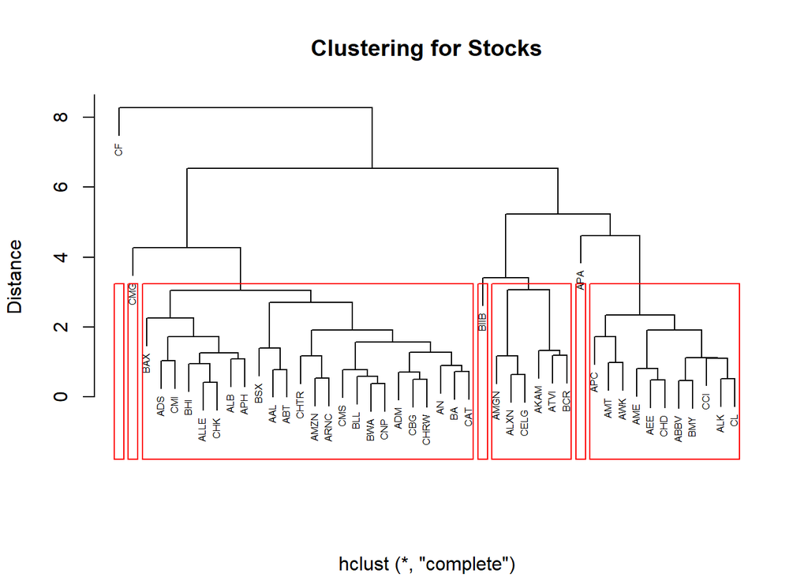

```r
# Get distance matrix
data_dist <- dist(data_f[,-1], method="euclidean")

# Perform cluster analysis
data_clust <- hclust(data_dist, method = "complete")

# Make dendrogram
plot(data_clust, xlab="",ylab="Distance", cex = .5, main="Clustering for Stocks")

# Identify groups
#rect.hclust(data_clust, k=5)
rect.hclust(data_clust,k=7)
```

**In this first model distance was calculated using the Euclidean method and a complete agglomeration method. The last command asks R to identify 7 clusters, since our data contains roughly 7 industries, and we think that might influence variables like risk and profit margin. From the dendogram, though, we can see three relatively larger clusters and four small single-stock clusters (CF, CMG, BIIB, APA). The left-most large cluster on the tree contains a variety of stocks, including those from companies in communications and manufacturing. The second cluster is smaller, but more specific to medical and other technology. The last cluster has a large number of stocks related to utilities and household products.**

#### Model 2

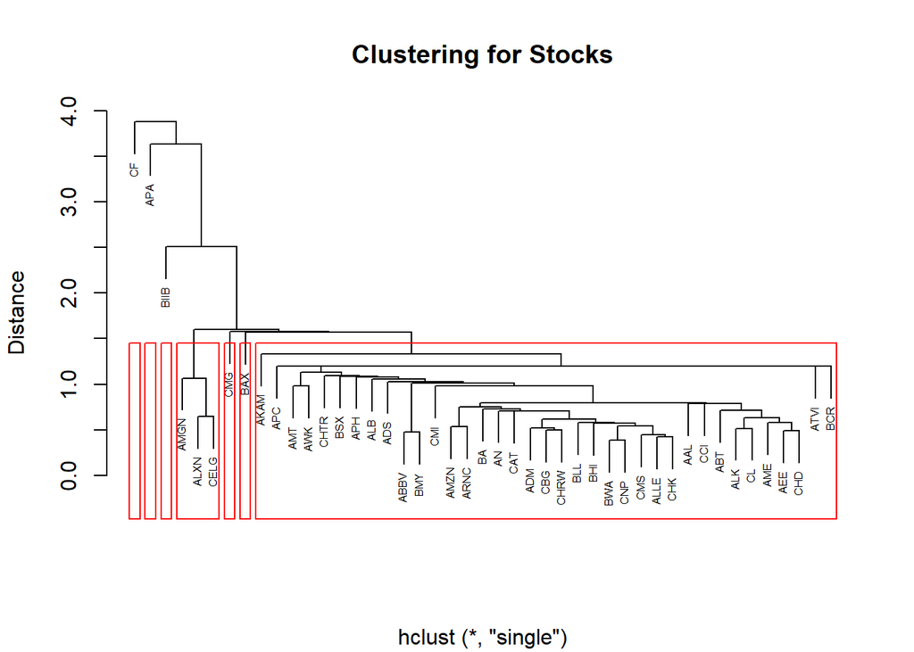

```r
# Get distance matrix
data_dist_2 <- dist(data_f[,-1], method = "euclidean")

# Perform cluster analysis
data_clust_2 <- hclust(data_dist_2, method = "single")

# Make dendrogram
plot(data_clust_2, xlab="",ylab="Distance",main="Clustering for Stocks", cex = .5)

# Identify groups
rect.hclust(data_clust_2, k=7)
```

**Model 2 used a “single” agglomeration method, which ought to produce more distinct groups. In this case, however, we obtained one large cluster that includes most of the stocks, and a few scattered ones toward the left-hand side of the dendogram. After seeing the results of single agglomeration, it does not appear to be particularly useful for cluster analysis, so we decided to proceed without using this agglomeration method again.**

#### Model 3

Manhattan + Complete

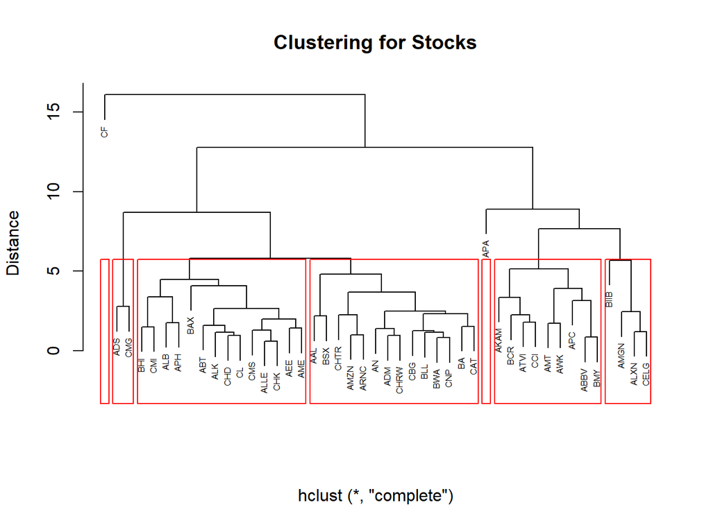

```r
# Get distance matrix
data_dist_3 <- dist(data_f[,-1], method = "manhattan")

# Perform cluster analysis
data_clust_3 <- hclust(data_dist_3, method = "complete")

# Make dendrogram
plot(data_clust_3, xlab="",ylab="Distance",main="Clustering for Stocks", cex = .5)

# Identify groups
rect.hclust(data_clust_3,k=7)
```

**Since the Manhattan distance calculation could work well for high-dimensional datasets, and also places less weight upon outliers, we also decided to see whether a different distance calculation would produce different clusters from the Euclidean distance method. In fact, this method obtains four groups with more stocks in them. While these groups do not directly correspond with different industries, the right-most cluster is composed of large pharmaceutical stocks, while another cluster is composed of mainly tech, media, and communications related stocks. The mix of stocks that do not align with industry might have something to do with market share or company size–we can see that several large companies, like Amazon, CenterPoint Energy and Boeing are all located in one cluster.**

### Model 4

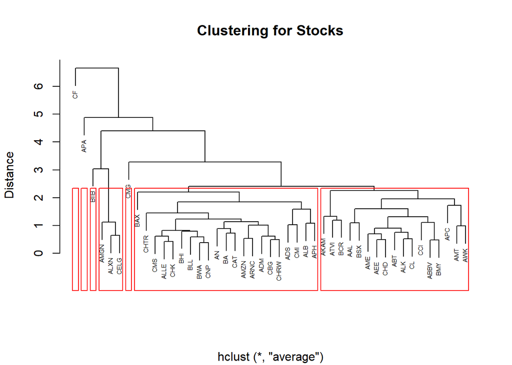

```r
# Get distance matrix
data_dist_6 <- dist(data_f[,-1], method = "euclidean")
# Perform cluster analysis
data_clust_6 <- hclust(data_dist_6, method = "average")
# Make dendrogram
plot(data_clust_6, xlab="",ylab="Distance", main="Clustering for Stocks", cex = .5)
# Identify three groups
rect.hclust(data_clust_6, k=7)
```

## PROBLEM 3

3. If possible, run the SAS macro or the R function to think about how many groups you want to retain (i.e. get the plots of cluster distance, R-squared, etc). If you can’t run this, discuss how many groups you think are present.

**We utilise the Euclidian distance method to compute distances and intiate clustering. Euclidean distance is particularly meaningful as our subsetted data set only includes continuous variables. We utilise Ward’s method for hierarchical clustering for two reasons. First, there may be a few outliers, and simple linkage is sensitive to outliers. Second, as explained in the lecture “several studies of clustering suggest that Ward’s method or Average Linkage work the ‘best’” (pg. 324, Cluster Analysis Lecture). We opt for 7 clusters along industry lines to begin when we plot the dendogram as we hypothesise that the stocks could–– as mentioned previously–– potentially be divided as such. Our observations of the stocks suggest that there are 7 relevant industries. We included these industries and stock breakdown in the end of this analysis, under Question 5. When we perform distance cluster analysis with 7 clusters, the result appears to match our hypothesis–that the clustering of companies supports a similar narrative.**

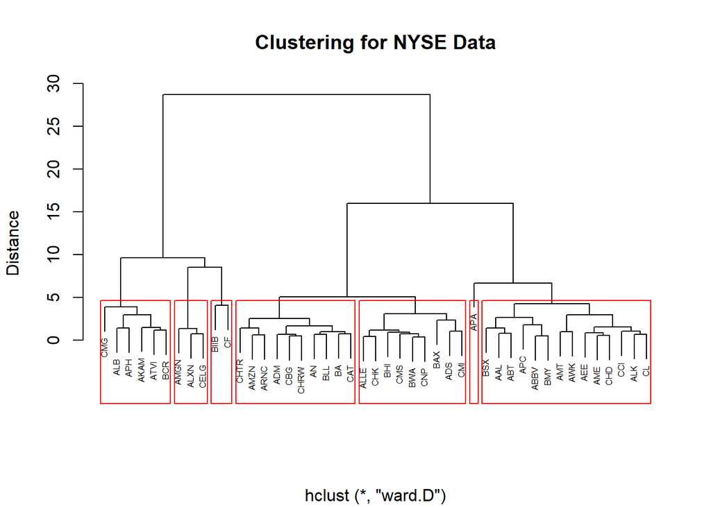

```r
# Using the Euclidean distance method to compute distances to begin the clustering process
dist1 <- dist(data_f, method="euclidean")

#We run the hclust() command to create the Hierarchical Ward Cluster (using Euclidean distance).
clust1 <- hclust(dist1, method="ward.D")

# We plot the dendogram of our data with 7 clusters.
plot(clust1, cex=.9, xlab="",ylab="Distance",main="Clustering for NYSE Data", cex = .5)
rect.hclust(clust1,k=7)
```

[output not shown]

[output not shown]

[output not shown]

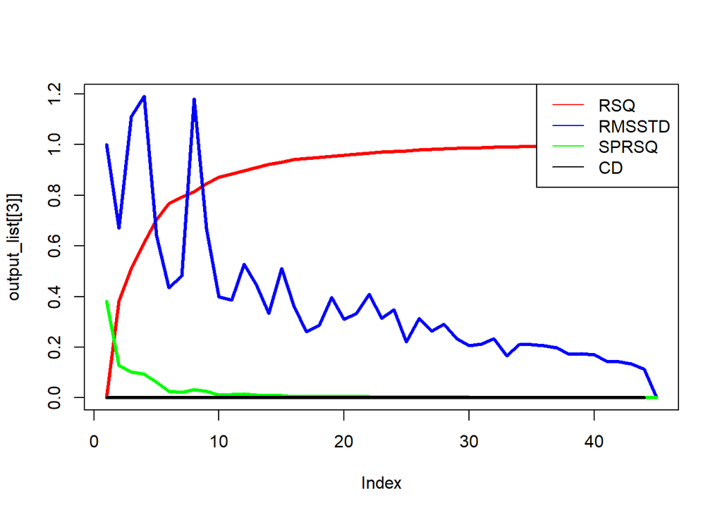

```
## [[1]]
##
## Call:
## hclust(d = dist1, method = clus_m)
##
## Cluster method   : ward.D
## Distance         : euclidean
## Number of objects: 45
##
##
## [[2]]
##  [1] 1.0000000 0.6694337 1.1122066 1.1909486 0.6400930 0.4354933 0.4817678
##  [8] 1.1807627 0.6687721 0.3991059 0.3857770 0.5290575 0.4457276 0.3332113
## [15] 0.5122562 0.3617457 0.2607688 0.2860754 0.3961159 0.3100152 0.3334677
## [22] 0.4094691 0.3132677 0.3483969 0.2211766 0.3142430 0.2634327 0.2911844
## [29] 0.2344589 0.2069490 0.2122070 0.2327383 0.1662922 0.2112981 0.2102045
## [36] 0.2061939 0.1979438 0.1714831 0.1750057 0.1689388 0.1452462 0.1433703
## [43] 0.1331432 0.1132957 0.0000000
##
## [[3]]
##  [1] 0.0000000 0.3827567 0.5109118 0.6122827 0.7050773 0.7668674 0.7927816
##  [8] 0.8151036 0.8467900 0.8721690 0.8836434 0.8960930 0.9105959 0.9221697
## [15] 0.9312389 0.9409222 0.9464032 0.9505913 0.9546899 0.9590634 0.9627360
## [22] 0.9665595 0.9703700 0.9738161 0.9765747 0.9788108 0.9810550 0.9833189
## [29] 0.9852460 0.9870235 0.9886866 0.9900849 0.9913159 0.9922812 0.9932959
## [36] 0.9943001 0.9952664 0.9961569 0.9970140 0.9977101 0.9983588 0.9988382
## [43] 0.9993054 0.9997083 1.0000000
##
## [[4]]
##  [1] 0.3827567197 0.1281550769 0.1013709358 0.0927945558 0.0617900818
##  [6] 0.0259142448 0.0223220333 0.0316863773 0.0253789341 0.0114744627
## [11] 0.0124496214 0.0145028809 0.0115737283 0.0090692467 0.0096832737
## [16] 0.0054810193 0.0041880974 0.0040986047 0.0043735286 0.0036725422
## [21] 0.0038235062 0.0038105674 0.0034460540 0.0027586457 0.0022360141
## [26] 0.0022442883 0.0022639055 0.0019270080 0.0017775231 0.0016631233
## [31] 0.0013982570 0.0012310713 0.0009652341 0.0010147022 0.0010042260
## [36] 0.0009662712 0.0008904940 0.0008571922 0.0006960680 0.0006486433
## [41] 0.0004794650 0.0004671600 0.0004028890 0.0002917253 0.0000000000
##
## [[5]]
##  [1] 0 0 0 0 0 0 0 0 0 0 0 0 0 0 0 0 0 0 0 0 0 0 0 0 0 0 0 0 0 0 0 0 0 0 0
## [36] 0 0 0 0 0 0 0 0 0
```

```r
# Loading the hclus_eval code
source("http://reuningscherer.net/stat660/R/HClusEval.R.txt")

# Running hclus_eval to produce the aforementioned guidance statistics; we use the Euclidean method for distances and the Ward method for clustering once again.
hclus_eval(data_f, dist_m = 'euclidean', clus_m = 'ward', plot_op = T)
```

## PROBLEM 4

4. Run k-means clustering on your data. Compare results to what you got in 3.) Include a sum of squares vs. k (number of clusters) plot and comment on how many groups exist.

```r
set.seed(10)
```

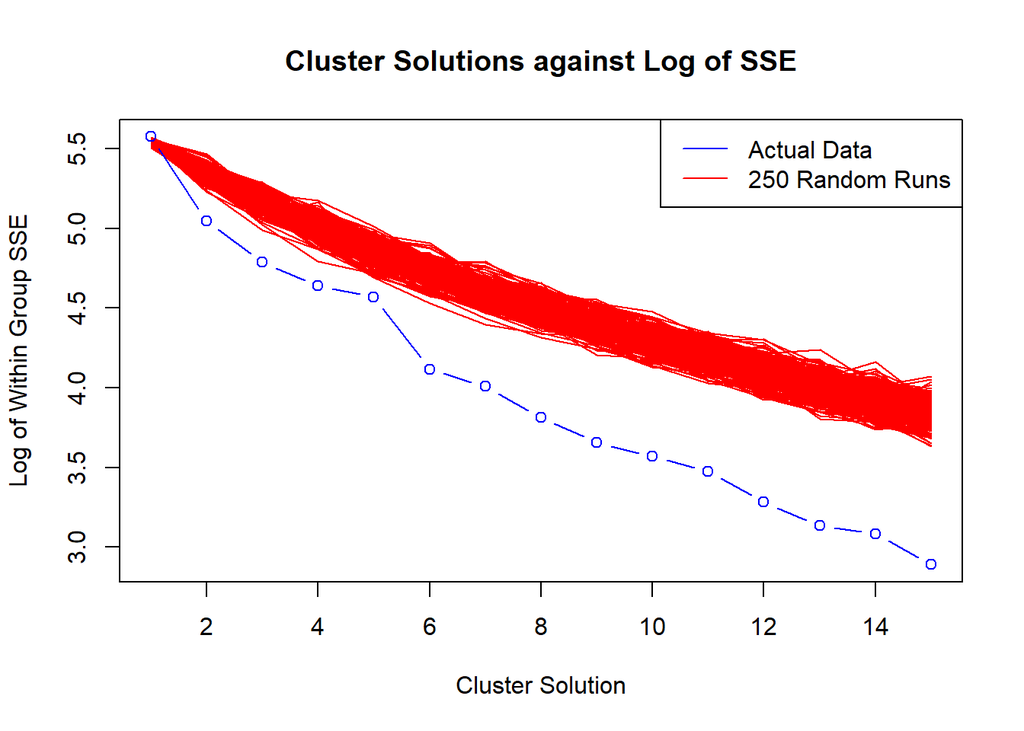

```r
# kdata is just normalized input dataset
kdata <- data_f
# Set max value for number of clusters k
n.lev <- 15
# Calculate the within groups sum of squared error (SSE)
#for the number of cluster solutions selected by the user
wss <- rnorm(10)
while (prod(wss==sort(wss,decreasing=T))==0) {
  wss <- (nrow(kdata)-1)*sum(apply(kdata,2,var))
  for (i in 2:n.lev) wss[i] <- sum(kmeans(kdata, centers=i)$withinss)}
# Calculate the within groups SSE for 250
#randomized data sets (based on the original input data)
k.rand <- function(x){
  km.rand <- matrix(sample(x),dim(x)[1],dim(x)[2])
  rand.wss <- as.matrix(dim(x)[1]-1)*sum(apply(km.rand,2,var))
  for (i in 2:n.lev) rand.wss[i] <- sum(kmeans(km.rand, centers=i)$withinss)
  rand.wss <- as.matrix(rand.wss)
  return(rand.wss)
}
rand.mat <- matrix(0,n.lev,250)
k.1 <- function(x) {
  for (i in 1:250) {
    r.mat <- as.matrix(suppressWarnings(k.rand(kdata)))
    rand.mat[,i] <- r.mat}
  return(rand.mat)
}
# Same function as above for data with < 3 column variables
k.2.rand <- function(x){
  rand.mat <- matrix(0,n.lev,250)
  km.rand <- matrix(sample(x),dim(x)[1],dim(x)[2])
  rand.wss <- as.matrix(dim(x)[1]-1)*sum(apply(km.rand,2,var))
  for (i in 2:n.lev) rand.wss[i] <- sum(kmeans(km.rand, centers=i)$withinss)
  rand.wss <- as.matrix(rand.wss)
  return(rand.wss)
}
k.2 <- function(x){
  for (i in 1:250) {
    r.1 <- k.2.rand(kdata)
    rand.mat[,i] <- r.1}
  return(rand.mat)
}
# Determine if the data data table has > or < 3
#variables and call appropriate function above
if (dim(kdata)[2] == 2) { rand.mat <- k.2(kdata) } else { rand.mat <- k.1(kdata) }
# Plot within groups SSE against all tested cluster solutions
#for actual and randomized data - 1st: Log scale, 2nd: Normal scale
xrange <- range(1:n.lev)
yrange <- range(log(rand.mat),log(wss))
plot(xrange,yrange, type='n', xlab='Cluster Solution', ylab='Log of Within Group SSE', main='Cluster Solutions against Log of SSE')
for (i in 1:250) lines(log(rand.mat[,i]),type='l',col='red')
lines(log(wss), type="b", col='blue')
legend('topright',c('Actual Data', '250 Random Runs'), col=c('blue', 'red'), lty=1)
```

**We calculate the internal sum of squares distances through 250 random partitions with the same number of clusters, each having the same sample size as their respective k-means partition counterparts.**

**In the next step, we will check the difference between SSE of the actual data and the SSE of 250 randomized datasets.**

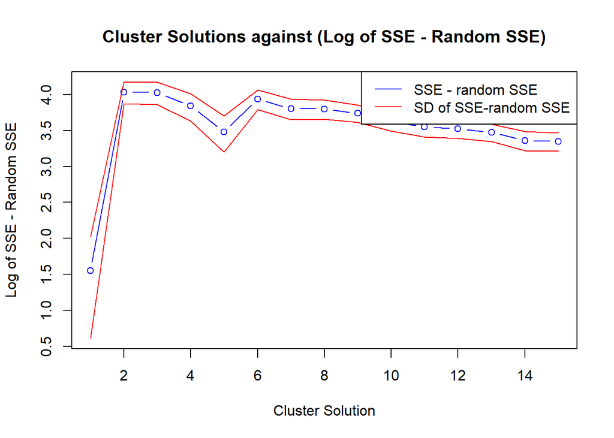

```r
# Calculate the mean and standard deviation of
#difference between SSE of actual data and SSE
#of 250 randomized datasets
r.sse <- matrix(0,dim(rand.mat)[1],dim(rand.mat)[2])
wss.1 <- as.matrix(wss)
for (i in 1:dim(r.sse)[2]) {
  r.temp <- abs(rand.mat[,i]-wss.1[,1])
  r.sse[,i] <- r.temp}
r.sse.m <- apply(r.sse,1,mean)
r.sse.sd <- apply(r.sse,1,sd)
r.sse.plus <- r.sse.m + r.sse.sd
r.sse.min <- r.sse.m - r.sse.sd

# Plot difference between actual SSE mean SSE
#from 250 randomized datasets - 1st: Log scale, 2nd: Normal scale

xrange <- range(1:n.lev)
yrange <- range(log(r.sse.plus),log(r.sse.min))
plot(xrange,yrange, type='n',xlab='Cluster Solution', ylab='Log of SSE - Random SSE', main='Cluster Solutions against (Log of SSE - Random SSE)')
lines(log(r.sse.m), type="b", col='blue')
lines(log(r.sse.plus), type='l', col='red')
lines(log(r.sse.min), type='l', col='red')
legend('topright',c('SSE - random SSE', 'SD of SSE-random SSE'), col=c('blue', 'red'), lty=1)
```

**This analysis focuses on the difference between the average of the red lines and the blue lines. We see that after 6 clusters, we do not observe much change in the difference between the averages, which is to say adding addition clusters beyond 6 did not really bring any further improvement. This matches the result we obtained in the previous section in our analysis that included 250 simulated data sets.**